# Relationship between odonates traits and their conservation

If we look at the impurity, the most important variables to predict status are mean temperature, habitat, body size and temperature variation. All these variables except body size also decrease accuracy, so they are not correlated to other variables.

To guess in which directions these variables affect the status, we look at the plots below:

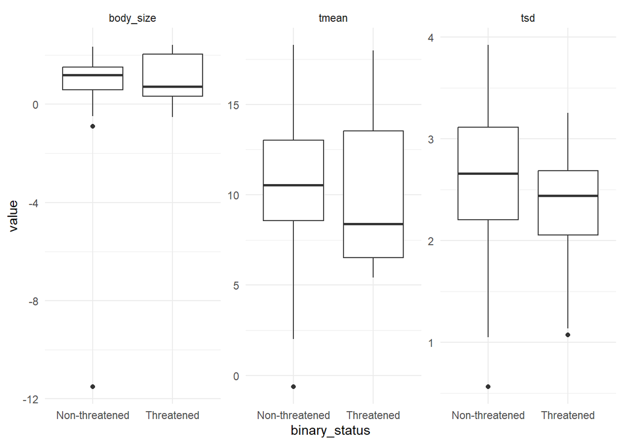

```r
df_boxplots <- df_bstatus |>
  select(binary_status, tmean, body_size, tsd) |>
  pivot_longer(cols = c(tmean, body_size, tsd))

ggplot(df_boxplots) +
  geom_boxplot(aes(x = binary_status, y = value)) +
  theme_minimal() +
  facet_wrap(vars(name), scales = "free_y")
```

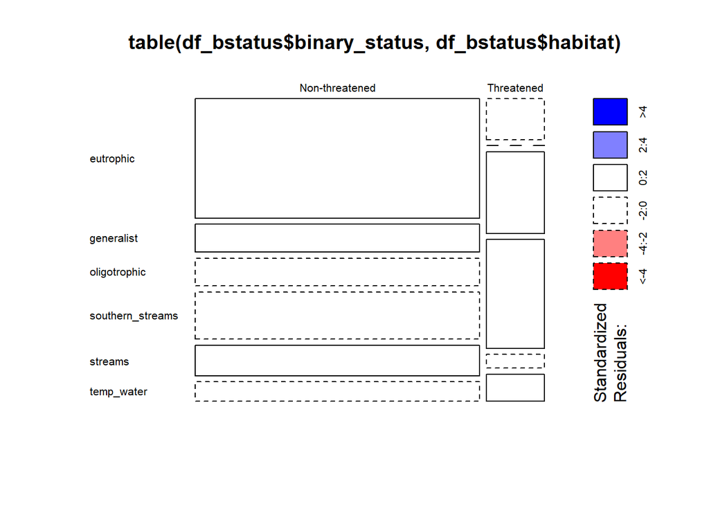

```r
mosaicplot(table(df_bstatus$binary_status, df_bstatus$habitat),
           shade = TRUE, las = 1)
```

Threatened species are usually smaller, found in habitats with lower and less variable temperature and occur mainly in oligotrophic habitats, southern streams and temporary waters.

### 8.3 Trend

Next, we do a random forest on trend.

```r
df_trend <- cbind(df_fac |> select(trend),
                   df_mvar)
df_trend <- na.omit(df_trend)

table(df_trend$trend)
```

```
Decreasing     Stable Increasing
        35         49         29
```

```r
rf_trend <- randomForest(
  formula = trend ~ .,
  data = df_trend,
  localImp = TRUE,
  ntree = 5000,
  mtry = 5,
  strata = df_trend$trend,
  importance = TRUE,
  sampsize = c(10, 10, 10)
)
```

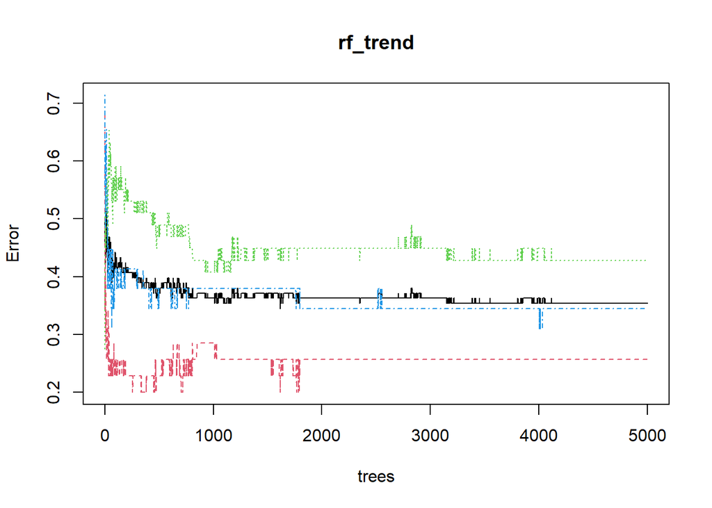

```r
plot(rf_trend)
```

The error decreases with the number of trees, but is still moderately large (see below).

```r
rf_trend
```

```
Call:
 randomForest(formula = trend ~ ., data = df_trend, localImp = TRUE,      ntree = 5000, mtry = 5, strata = df_trend$trend, importance = TRUE,      sampsize = c(10, 10, 10))
               Type of random forest: classification
                     Number of trees: 5000
No. of variables tried at each split: 5

        OOB estimate of  error rate: 35.4%
Confusion matrix:
           Decreasing Stable Increasing class.error
Decreasing         26      6          3   0.2571429
Stable             10     28         11   0.4285714
Increasing          1      9         19   0.3448276
```

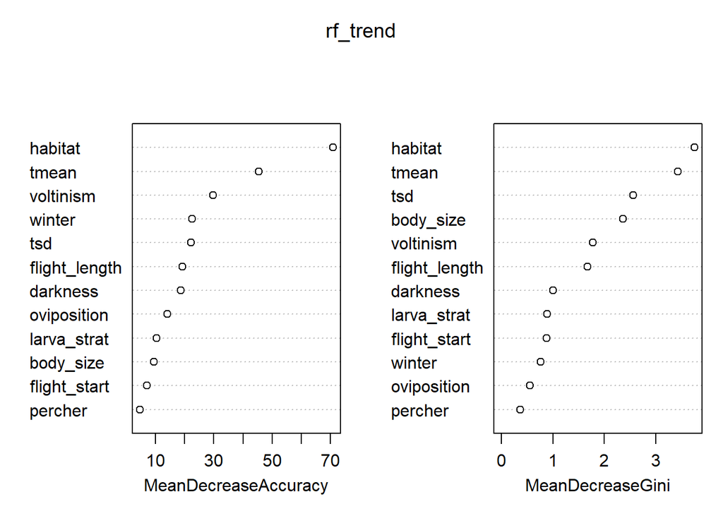

```r
varImpPlot(rf_trend)
```

To interpret the direction of the effect, we consider the plots below:

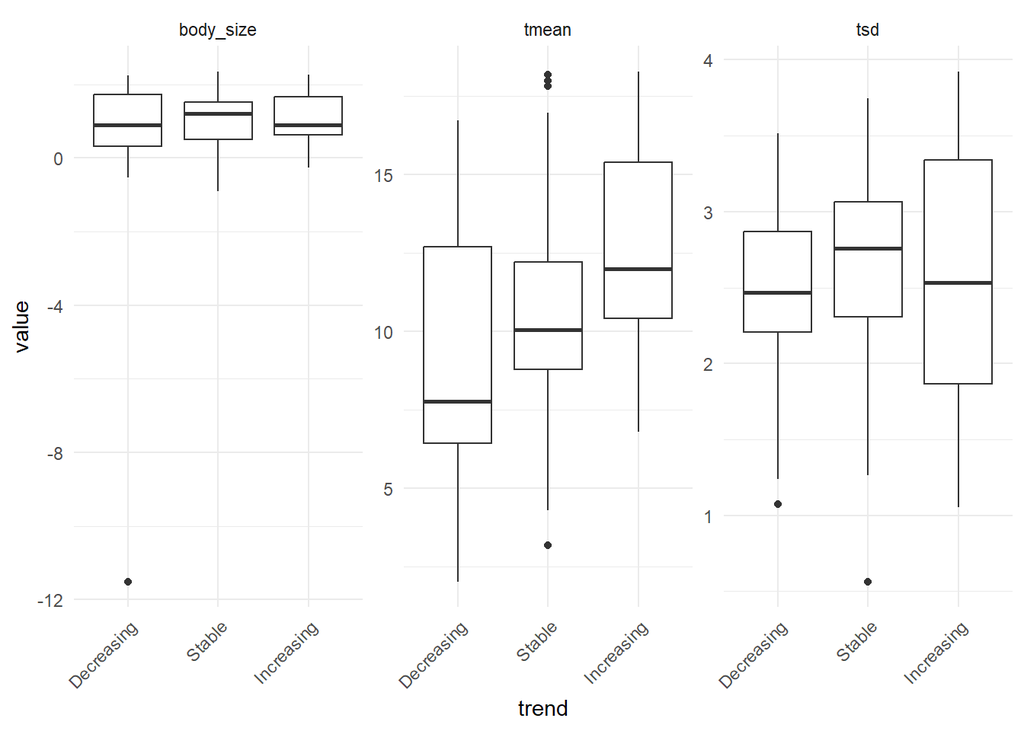

```r
df_boxplots <- df_trend |>
  select(trend, tmean, body_size, tsd) |>
  pivot_longer(cols = c(tmean, body_size, tsd))

ggplot(df_boxplots) +
  geom_boxplot(aes(x = trend, y = value)) +
  facet_wrap(vars(name), scales = "free_y") +
  theme_minimal() +
  theme(axis.text.x = element_text(angle = 45, hjust = 1))
```

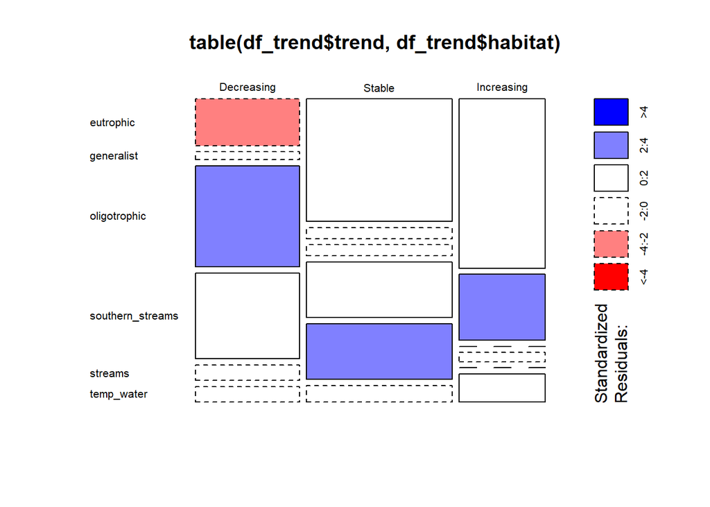

```r
mosaicplot(table(df_trend$trend, df_trend$habitat),
           shade = TRUE, las = 1)
```

Decreasing species tend to be smaller, occur in colder and less variable in temperature habitats. They also tend to occur more in oligotrophic habitats and southern streams and less in eutrophic habitats, while increasing species tend to be eutrophic, generalist or temporary water species.

### 8.4 Area of occupancy

```r
df_area <- cbind(df_fac |> select(area),
                 df_mvar)
```

```r
rf_area <- randomForest(
  formula = area ~ .,
  data = df_area,
  importance = TRUE,
  ntree = 500
)
```

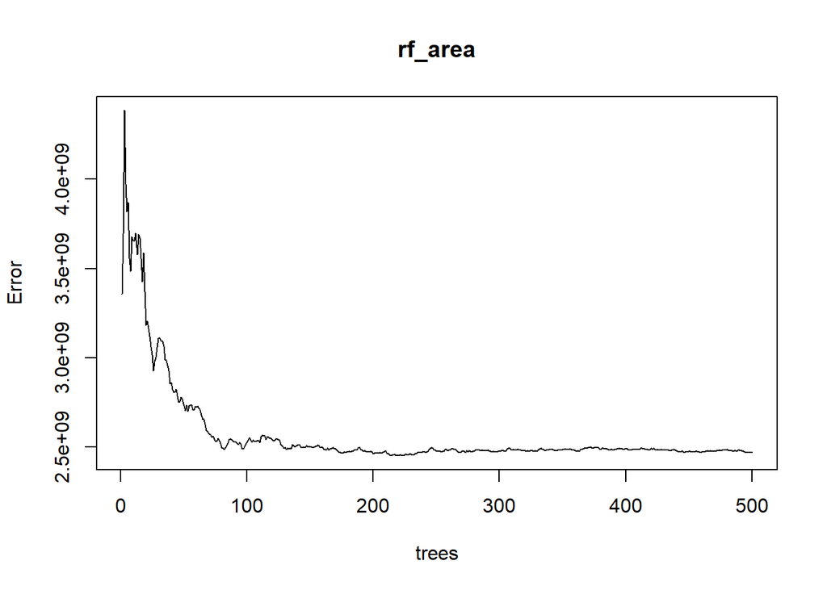

```r
plot(rf_area)
```

With this model, the error metric is different as we use mean square error (MSE) to measure error (since we predict a quantitative variable). The MSE decreases with the number of trees.

```r
rf_area
```

```
Call:
 randomForest(formula = area ~ ., data = df_area, importance = TRUE,      ntree = 500)
               Type of random forest: regression
                     Number of trees: 500
No. of variables tried at each split: 4

          Mean of squared residuals: 2471390699
                    % Var explained: 50.95
```

This model explains about 50 % of variance of area of occupancy by traits.

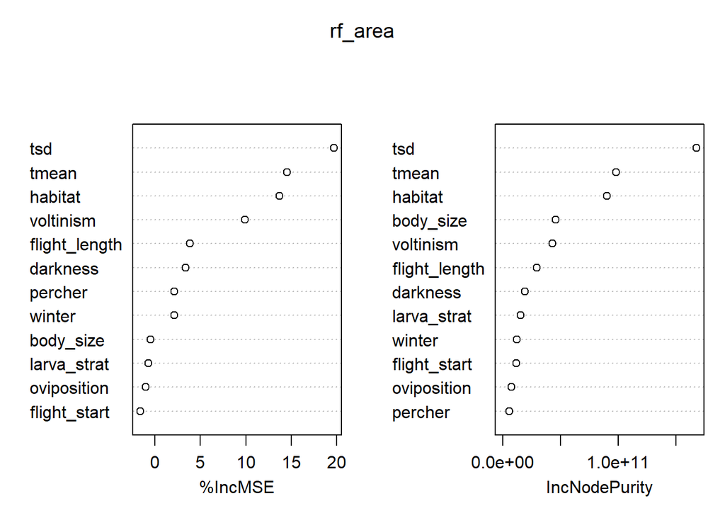

```r
varImpPlot(rf_area)
```

The metrics measuring variable importance are also different from the previous random forest models here, as the predicted variable (area of occupancy) is quantitative, but their interpretation is the same.

- the left graph quantifies the increase in Mean Square Error (MSE) when the variable is permuted. As previously, it indicates if the predictor is redundant.
- the right graph quantifies the increase in node purity, i.e. the the residual sum of squares explained by a node split using this predictor.

Based on these metrics, the most important traits to determine species area of occupancy are temperature variability and mean and habitat (right graph). These variables also rank first in the increase of MSE (left graph), which indicates that they are not redundant with other variables.

To guess the direction of the effect, let’s look at these graphs:

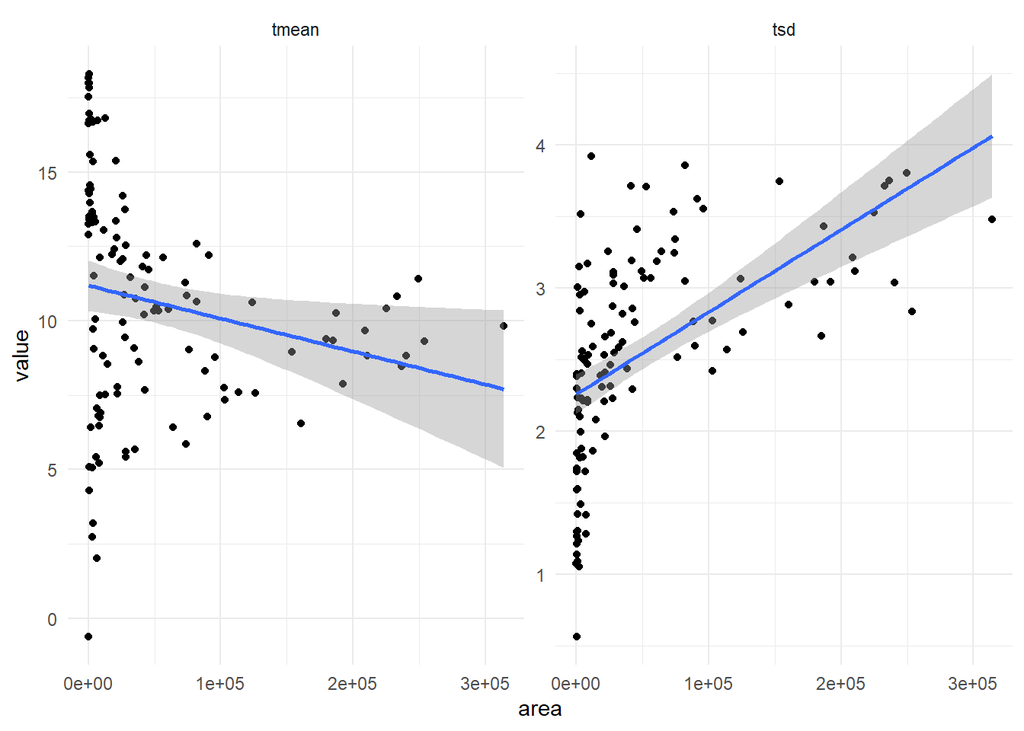

```r
df_points <- df_area |>
  select(area, tmean, tsd) |>
  pivot_longer(cols = c(tmean, tsd))

ggplot(df_points,
       aes(x = area, y = value)) +
  geom_point() +
  geom_smooth(method = "lm") +
  theme_minimal() +
  facet_wrap(vars(name), scales = "free_y")
```

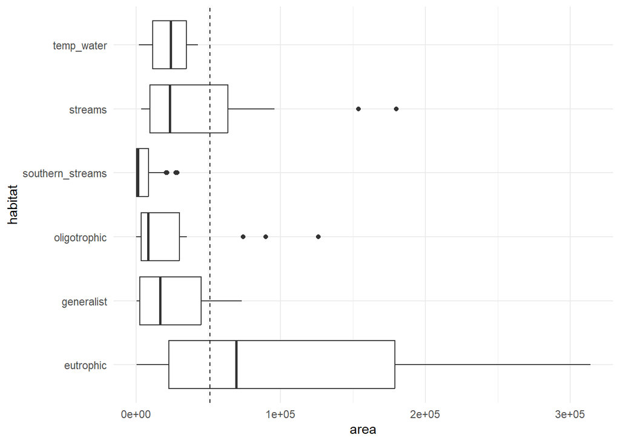

```r
ggplot(df_area) +
  geom_boxplot(aes(y = habitat,
                   x = area)) +
  theme_minimal() +
  geom_vline(xintercept = mean(df_area$area),
             linetype = "dashed")
```

Species with a smaller area of occupancy tend to live in warmer places with less temperature variability, and are often southern streams or oligotrophic species.

### 8.5 Summary of random forest analyses

The analyses on binary status, trend and area of occupancy are in agreement to define the most important traits for these conservation indicators, which are:

- habitat
- mean temperature
- standard deviation of temperature

Strictly, random forests don’t allow to estimate the direction of the effect. However, we can guess by examining the relationship between predictors and response variable in the dataset. Following this guess, almost all analyses find the same direction of the effect of these traits on conservation metrics. Indeed, threatened species, decreasing species and species occurring in small areas tend to:

- live in places that have less variable temperatures;
- prefer oligotrophic and southern streams habitats.

The picture for mean temperature is a little different, as:

- decreasing and threatened species live in colder places;
- species occurring in small areas live in warmer places.

## 9 Methods comparison

Below, we compare the results obtained with multivariate analyses or random forest for each conservation metric.

### 9.1 Binary status

For binary status, discriminant analysis defines:

- non-threatened species as eutrophic, long and early flight, generalist species with a large temperature range;
- threatened species as oligotrophic, southern streams, sediment oviposition, short and late flight, sprawler larvae.

Random forest cannot directly determine the direction of the relationship. However, with a visual examination of data, it gives:

- non-threatened species as found in habitats with higher and more variable temperature that occur mainly in eutrophic, generalist or streams habitats;
- threatened species as found in habitats with lower and less variable temperature and occur mainly in oligotrophic habitats, southern streams and temporary waters.

Both methods are in agreement to select habitat and temperature range as important variables, and the direction of the effect seems to be similar. However, mean temperature doesn’t appear in the multivariate analysis, and flight, larvae strategies and oviposition don’t appear in the random forest.

### 9.2 Trends

For the discriminant analysis:

- increasing species tend to be multivoltine, light species, with long and early flight, that are eutrophic and generalist that prefer warm environments;
- decreasing species tend to be partivoltine, live in oligotrophic habitats or southern streams, be dark, short and late flights species and prefer cold environments.

For random forest:

Both methods are in agreement for the habitat and mean temperature, but temperature variability doesn’t appear in the multivariate analysis, and darkness, flight and voltinism don’t appear in the random forest.

### 9.3 Area of occupancy

For the redundancy analysis:

- large area species tend to be eutrophic species that tolerate a high temperature range;
- small area of occupancy species tend to be in southern streams, temporary water, generalist or oligotrophic species, with burrower larvae that have a sediment oviposition and tolerate a narrow temperatire range.

For the random forest:

- large area species tend to live in colder places with more temperature variability and be eutrophic or streams species;
- smaller area species tend to live in warmer places with less temperature variability, and are often southern streams or oligotrophic species.

Both methods agree for habitat and temperature variability, but mean temperature doesn’t appear in RDA and larval stragegy and oviposition don’t appear in random forest.

## 10 Summary of the results

In this document, I used two different methods to study the relationship between traits and species conservation status, evaluated with 4 metrics (status, binary status, trend and area).

All analyses converge to point habitat as an important factor for species conservation, with an opposition between eutrophic species (that tend to have a favorable status), and oligotrophic species (and sometimes also southern streams species) that tend to have a less favorable status.

Some analyses agree that temperature mean and variability are also important factors, with species living in colder and less variable environments having a generally less favorable status. In particular, mean temperature is found to affect species trends with both methods, while temperature range affects species’ binary status and area of occupancy for both methods. Finally, multivariate analysis also point the role of generalist species and flight phenology (status + trend), sediment oviposition (status + area) and voltinism (trends).